# Using RStudio

## 2.7 Packages

- Next, let’s look at the **Packages** tab.

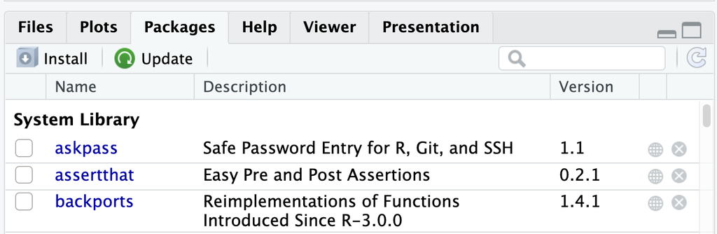

- **Packages are collections of R code that extend the functionality of R**. More details will be provided on packages as we progress.

### 2.7.1 Base R packages

- Knowing what **base R packages** are available helps you understand which functions and datasets come with R by default (without needing to install anything)
- To see the base R, packages, we can run the following code

```r
installed.packages(priority = "base")
```

- This shows core R packages that are essential for R to run (like stats, utils, graphics, etc.).
- To include the “recommended” ones (those that come preinstalled but can be updated), use:

```r
installed.packages(priority = c("base", "recommended"))
```

### 2.7.3 Package installation

- For now, it is important to know that to use a package, you need to *install* then *load* it. **Packages need to be installed only once, but must be loaded in each new R session**.
- All the package names you see (in blue font) are packages that are installed on your system. And packages with a checkmark are packages which are *loaded* in the current session.
- You can install a package with the Install button of the Packages tab.

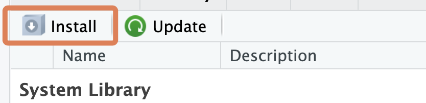

- But it is better to install and load packages with R code, rather than the Install button. Let’s try this. Type and run the code below to install the {pacman} package.

```r
install.packages("pacman")
library(pacman)
```

- The first line installs the package. The second line *loads* the package from your package library.
- Because you only need to install a package once, you can now remove the installation line from your script (*see commenting in R*).
- Packages that have already been installed can also be updated. You can either update a single package or all packages already installed in R
- Most packages in R come with datasets, and thus one can use the datasets for analysis

## 2.9 Help

- Lastly, the **Help** tab shows the documentation for different R objects. Try typing out and running each line below to see what this documentation looks like.

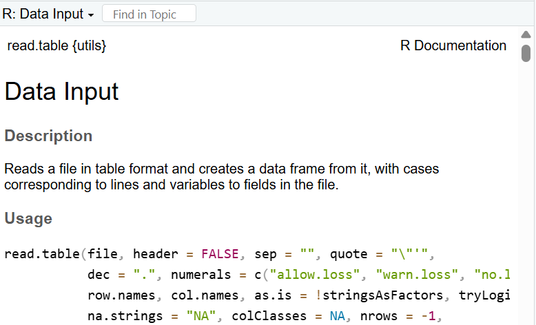

```r
?data
?read.csv
```

- Help files are not always very easy to understand for beginners, but with time they will become more useful.

# 3 RStudio options

[figure not shown]

- Under `Code > Display`, check “Highlight R function calls”. What this does is give your R *functions* a unique color, improving readability. This will come clear later as we progress.
- Also under `Code > Display`, check “Rainbow parentheses”. What this does is make your “nested parentheses” easier to read by giving each pair a unique color.

[figure not shown]

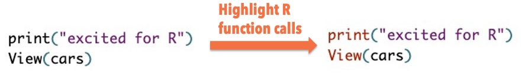

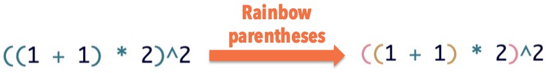

- Under the `Code > Display`, you can also adjust the margin of the code from the default `80` to another number of choice.
- Finally under `General > Basic`, **uncheck** the box that says **“Restore .RData into workspace at startup”**. You don’t want to restore any data to your workspace (or *environment)* when you start RStudio. Starting with a clean workspace each time is less likely to lead to errors.

  This also means that you never want to **“save your workspace to .RData on exit”**, so set this to **Never**.

# 4 Command palette

- The Rstudio command palette gives instant, searchable access to many of the RStudio menu options and settings that we have seen so far.
- The palette can be invoked with the keyboard shortcut `Ctrl` + `Shift` + `P` (`Cmd` + `Shift` + `P` on macOS).
- It’s also available on the *Tools* menu (*Tools* -> *Show Command Palette*).

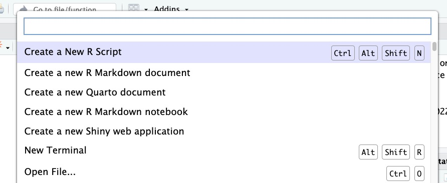

Try using it to:

- Create a new script (Search “new script” and click on the relevant option)
- Rename a script (Search “rename” and click on the relevant option)

# 5 Wrapping up

- As you advance in your R journey, you will discover new features, and you will hopefully grow to love the wonderful integrated development environment (IDE) that is RStudio.
- One good place to start is the official RStudio IDE [cheatsheet](https://rstudio.github.io/cheatsheets/html/rstudio-ide.html).

[figure not shown]